# Scorigami!

Using Markov Chains to Model Unique NFL Game Scores

Austin Redmond

4/12/2019

# Introduction

#### Project Description and Objectives

Scorigami is the “art of achieving a final score in an NFL game that has never happened before” (Bois). John Bois, an editor and sportswriter at SB Nation (Colon), invented the term Scorigami in December of 2016. The final score of an NFL game consists of the total points scored by each of the two teams. There are six ways to score points in an NFL game. The two most common ways to score are the 3-point field goal and 7-point touchdown with a successful point-after-attempt. The next three less common ways of scoring are the: 2-point safety; 6-point touchdown with a failed conversion; and the 8-point touchdown with a successful 2-point conversion. The final and nearly impossible way to score is the 1-point safety. The 1-point safety has never occurred in the NFL but it is technically possible as “a team making an extra-point attempt [could] botch the play so badly, they would end up in their own endzone, 98-yards away, and then get tackled in the endzone” (Nogle). The irregular distribution of scoring methods and the relatively smaller sample size from a limited number of exactly 256 regular season and 12 postseason games per year means that many final NFL scores that are possible have never actually happened. The website https://nflscorigami.com/ has a detailed representation of each final score that has and has not occurred. The topic of this project is related to using Markov Chains to project the probability of a unique final NFL score (otherwise known as a Scorigami) happening given parameters related to the the current score and how many quarters are yet to occur in the game.

#### Literature Review

No scholarly articles have been dedicated to the topic of scorigami. There has been literature presented on the use of Markov chains to predict outcomes in the NFL. For example, a Markov chain was used to model the, at the time, new overtime rule system where the team that wins the coin toss must score touchdown or concede safety for the overtime period to end on the first possession. The transition matrix was calculated using data on how a possession was most likely to end. The conclusion found that new rule mitigated the advantage the team that one the coin toss had in overtime (Jones).

Another article also used Markov chains to predict outcomes of NFL overtimes. In the second article, the transition matrix is constructed differently and simplified as certain ways of scoring were considered negligible. For example, a successful safety was not considered as a possible outcome because of its extremely low frequency (Leake). The conclusions found in the second article, was very similar to the conclusion found in the first article which justifies the simpler model in the second article

# Methodology

### My Library

Call my libary in order to use functions stored in another r script. The listed functions take the form.

game_data(gameIds, gamePlayByPlay) initial_distribution(states, givenState) multi_game_scrape(seasons, types, weeks = NULL, teams = NULL) multi_game_play_by_play(gameIDs) points_scored_frequency(gameData) points_scored_observations(pointsScoredFrequency) scorigami_probability(stateProbabilityDistribution, missingStates) state_probability_distribution(initialDistribution, transitionMarix, quarters remaining) transition_matrix_one(states, pointsScoredFrequency) transition_matrix_two(states, pointsScoredFrequency)

```r
source("~/GitHub/ScorigamiMC/ScorigamiMCLibrary.R")
```

### Data Scraping

#### Install nflscrapR

The data for this analysis was collected using nflscrapR which is an R package that is used to “utilize and analyze data from the National Football League (NFL) API” (How). It is necessary to install it in order to scrape data pertaining to NFL box scores. The nflscrapR package can be found at https://github.com/maksimhorowitz/nflscrapR. The devtools package can install R packages hosted on Github.

```r
#Load the devtools library to install packages found on github.
library(devtools)

#Install nflscrapR from the designated Github repository.
devtools::install_github(repo = "maksimhorowitz/nflscrapR")
```

#### Scrape Individual Games

Ten years worth of regular and post season games between 2009 and 2018 are collected for analysis. During this period, 2560 regular season games and 120 postseason games were played in the NFL. Each observation represents a unique game. Each game has 10 variables that record: a unique game ID; the game’s type which indicates whether the game is a regular season or postseason game; the home team; the away team; the week of the season that the game was played; the score of the home team at the end of the game; the score of the away team at the end of the game; a unique url associated with the game; and the status of the game indicating whether the game is finished or ongoing.

```r
#Scrape all regular and post season game ids from 2009 to 2018.
#scrapedGameIDs <- multi_scrape_game_ids(2009:2018, c("reg", "post")) #This is the original line.
load("scrapedGameIDs.Rda")

#Save scraped game ids to file.
save(scrapedGameIDs, file = "scrapedGameIDs.Rda")

#dplyr is used to select or deselect certain variables for in a data set.
library(dplyr)

#Display the first six observations.
head(select(scrapedGameIDs, -c("game_url", "state_of_game")))
```

```
##   type    game_id home_team away_team week season home_score away_score
## 1  reg 2009091000       PIT       TEN    1   2009         13         10
## 2  reg 2009091304       CLE       MIN    1   2009         20         34
## 3  reg 2009091307        NO       DET    1   2009         45         27
## 4  reg 2009091308        TB       DAL    1   2009         21         34
## 5  reg 2009091305       HOU       NYJ    1   2009          7         24
## 6  reg 2009091306       IND       JAC    1   2009         14         12
```

#### Scrape Game Play-by-Play

All previously scraped game IDs collected from 2009 to 2018 are used to get play-by-play data. Each observation represents a unique play. The only variables collected from the play-by-play were; the unique game id; the home team, the away team; the quarter the play happened; the home score; and the away score. All other variables were discarded. For this analysis, it is necessary to record the scores at the end of each of the 4 quarters because that is considered a state. All observations that are not indicated as resulting in the quarter ending are also discarded. This action is executed by conditioning the data on a variable that indicates whether the quarter ends immediately after the play occurs.

```r
#Load the scraped game ids data frame from file.
load("scrapedGameIDs.Rda")

#Scrape play-by-play data of all selected games.
#scrapedGamePlayByPlay <- multi_scrape_game_play_by_play(scrapedGameIDs)
load("scrapedGamePlayByPlay.Rda")

#Save scraped game play-by-play data to file.
save(scrapedGamePlayByPlay, file = "scrapedGamePlayByPlay.Rda")

#Display the first six observations.
head(scrapedGamePlayByPlay)
```

```
## # A tibble: 6 x 6
##   game_id    home_team away_team   qtr total_home_score total_away_score
##   <chr>      <chr>     <chr>     <dbl>            <dbl>            <dbl>
## 1 2009091000 PIT       TEN           1                0                0
## 2 2009091000 PIT       TEN           3                7                7
## 3 2009091000 PIT       TEN           4               10               10
## 4 2009091304 CLE       MIN           1                3                3
## 5 2009091304 CLE       MIN           2               12               10
## 6 2009091304 CLE       MIN           3               12               24
```

#### Combine Data Sets

The two data sets are merged together so that each observation in the merged data set will represent one game. The structure of the merged data set is the same as the scraped individual game data set. The score at the end of each quarter, which is information found in the play-by-play data set, is added to each observation in the merged data set.

```r
#Load both scraped datasets.
load("scrapedGameIDs.Rda")
load("scrapedGamePlayByPlay.Rda")

#Merge the scaped game Id dataset and the scraped game play-by-play data set.
gameData <- game_data(scrapedGameIDs, scrapedGamePlayByPlay)

#Save merged game data to file.
save(gameData, file = "gameData.Rda")
```

The first six observations demonstrate the limitations of how the data was originally recorded. Some plays that were the last play of the quarter were not properly recorded as such. When this error in the NFL’s records occurs, an NA will be recorded in the data set. It is not ideal to have missing data. However it is possible to proceed to the construction of the points scored distributions. If the score is missing at the end of one quarter for any game, there is still 2 or 3 quarters where the amount of points scored is known. That information can still be used to construct the points scored distributions.

```r
#Load the merged data set.
load("gameData.Rda")

#Display the first six observations.
head(gameData)
```

```
##      game_id home_team away_team qtr1_home_score qtr1_away_score
## 1 2009091000       PIT       TEN               0               0
## 2 2009091304       CLE       MIN               3               3
## 3 2009091307        NO       DET              14               3
## 4 2009091308        TB       DAL               0               6
## 5 2009091305       HOU       NYJ               0               3
## 6 2009091306       IND       JAC               0               0
##   qtr2_home_score qtr2_away_score qtr3_home_score qtr3_away_score
## 1            <NA>            <NA>               7               7
## 2              12              10              12              24
## 3              28              10              38              26
## 4            <NA>            <NA>               7              20
## 5               0              10               0              17
## 6            <NA>            <NA>              14               6
##   qtr4_home_score qtr4_away_score final_home_score final_away_score
## 1              10              10               13               10
## 2              19              34               20               34
## 3              45              26               45               27
## 4              21              34               21               34
## 5               6              24                7               24
## 6              14              12               14               12
```

### The Markov Chain Representation

#### Possible States

As described before, each state will include two scores. The first score is the winning team’s total points and the second score is the losing team’s total points. The winning and losing teams may be tied but (for this analysis) it is considered trivial which actual team is considered the winning and losing team. The minimum points scored by a team in one quarter is 0 points for the data set. On the other hand, the maximum points scored in one quarter by a team is 31 for the data set. Although unlikely, we consider the probability of a team scoring 31 points every quarter to have a non-zero probability. In an NFL game there are four steps representing a quarter that is played. By definition the final score of the winning team is always greater than or equal the final score of the losing team. The possible states are:

{“w-l”|w and l are elements of the set of integers between 0 and 124, w >= l}

```r
#Create a vector of states with the first element being the score "0-0".
states <- c("0-0")

#Loop through each of the possible states,"w-l".
#Add the result to the states vector.
for(w in 1:124) {
  for(l in 0:w) {
    states[[length(states)+1]] <- paste(w,l, sep ="-")
  }
}

#Save the states vector to file.
save(states, file="states.Rda")
```

#### Missing States

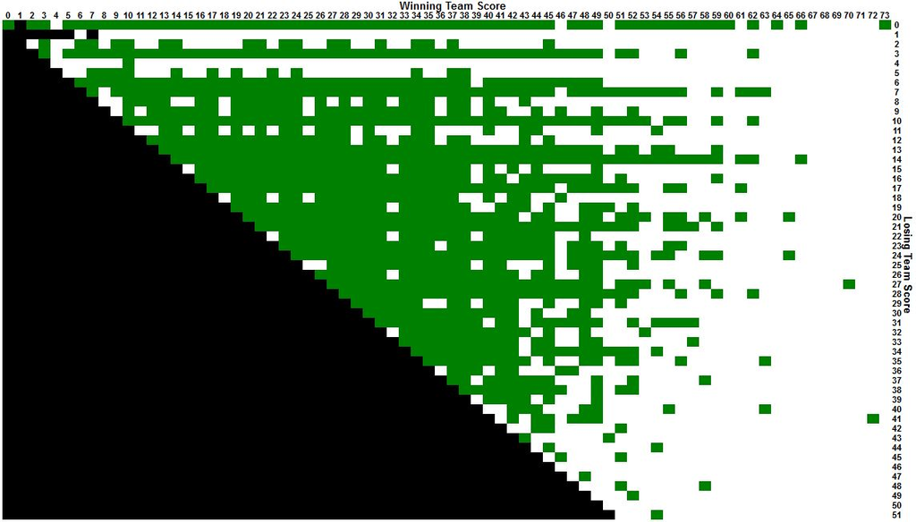

Scorigami Matrix Found at www.nflscorigami.com

The diagram above illustrates most of the possible states that are considered in this analysis. Black squares are not considered possible states. Green squares indicate that the final score has occurred at least once. The white squares represent a final score that has never occurred before. A scorigami occurs whenever a unique final score occurs for the first time. Pro football reference provides a data set including all the missing final scores that have never occurred before.

```r
#Load the missing score data from csv.
missingScoresData <- read.csv(file="missingScores.csv", header = TRUE, sep = ",")

#The all missing states between "2-2" and "70-70".
missingStates <- as.character(missingScoresData$Score)

#Add each state between "71-0" and "124-124"
for(w in 71:124) {
  for(l in 0:w) {
    missingStates[[length(missingStates)+1]] <- paste(w,l, sep="-")
  }
}

#Remove the states "72-41" and "73-0" because they have occurred before.
missingStates <- setdiff(missingStates, c("72-41", "73-0"))

save(missingStates, file="missingStates.Rda")
```

#### Initial Distribution

The initial distribution defines the probability of each state at the start. In the context of an NFL game, only one score can exist at a time. As every game starts with a score of 0 to 0, a standard initial distribution will have 100% probability of being state “0-0”. It is possible to start the projection at other points in time such as the start of the second, third, and fourth quarters. If this is the case, the number of transitions will need to reflect the different point in time.

```r
load("states.Rda")

standardInitialDistribution <- initial_distribution(states, "0-0")

save(standardInitialDistribution, file="standardInitialDistribution.Rda")
```

#### Points Scored Distributions

The first step in constructing the transition matrices is to determine the distribution of points scored by a team in a quarter. The winning team in a given quarter is defined as the team that is winning the game at the start of the quarter. While the losing team in a given quarter is defined as the team that is losing the game at the start of the quarter. If the teams are tied at the start of the quarter, then the team that scored more points in that quarter is considered the winning team. The winning team and losing team can change from quarter-to-quarter.

The graph below plots the points scored by the winning team and the losing team in one quarter for every quarter recorded in the data set. A single observation includes the points scored from both teams. The x-axis shows the quantity of points scored by the winning team in one quarter. The winning team has scored anywhere from 0 to 31 points. The x-axis shows the quantity of points scored by the losing team in one quarter. The losing team has scored anywhere from 0 to 28 points.

The color of each cell in the grid represents the amount of observations where the winning team and the losing team specifically scored that many points in a quarter. This means that we are treating the scores of the winning team and losing team as dependent. There are 10 colors representing ten bins. The first bin has a black color and each bin thereafter is a lighter color. The tenth bin therefore is yellow. Any cell that is white has no observations. The size of the bins were determined so that they contain roughly the same number of observations. They are as follows: bin 1 (1 observation), bin 2 (2 observations), bin 3 (3 observations), bin 4 (4-5 observations), bin 5 (6-9 observations), bin 6 (10-14 observations), bin 7 (14-50 observations), bin 8 (51-100 observations), bin 9 (101-150 observations), and bin 10 (151 observations or greater).

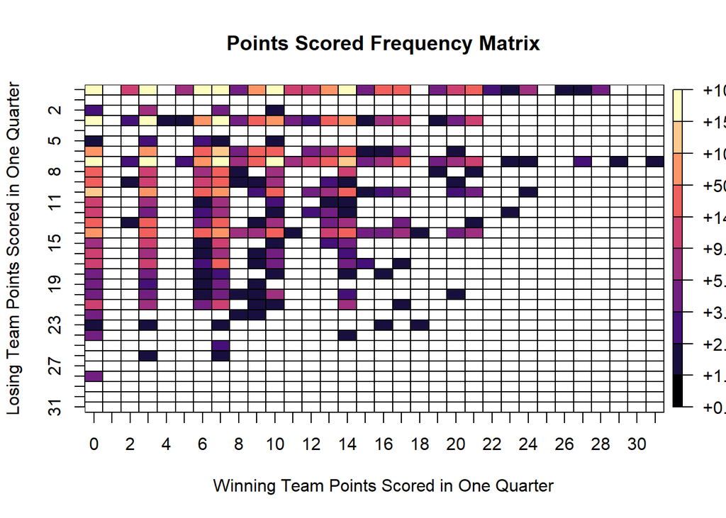

```r
#Load the game data.
load("gameData.Rda")

#Get the frequency of how many points are scored by the the two teams within the game data. This functiomn will return a matrix.
pointsScoredFrequency <- points_scored_frequency(gameData)

#Save the points scored frequency matrix to file.
save(pointsScoredFrequency, file="pointsScoredFrequency.Rda")

#Load the plot.matrix and viridis libraries to create a graph of the points scored frequency matrix.
library(plot.matrix)
library(viridis)

#Plot the points scored frequency matrix,
x <- pointsScoredFrequency
x[x==0] <- NA
plot(x, breaks=c(0,1,2,3,5,9,14,50,100,150,1000),col = magma, main="Points Scored Frequency Matrix", xlab = "Winning Team Points Scored in One Quarter", ylab = "Losing Team Points Scored in One Quarter")
```

When observing the graph, it is clear that many combinations of scores have not occurred in period of 2009 to 2018. Given the yellow cells, it is evident that the most common combinations of scores are those where both teams have a score that is a linear transformation of [3x+7y] where x and y are 0, 1, or 2. This result is intuitive given that: first the 3-point field goal and the 7-point touchdown with successful point-after attempt are the most common ways to score and second it is difficult to score on 3 or more drives in a quarter as each quarter is time constrained to 15 minutes of game time. Scores that are only possible using at least one 2-point safety and/or 8-point touchdown are very unlikely to occur. A few examples of unlikely amounts of points scored in a quarter are 2, 4, 5, 8, 11, and 15 to name a few. Columns or rows featuring a rare score like those mentioned are likely to be mostly white, black, or darker shades of purple.

The amount of points scored by the winning and losing teams may or may not be independent. Only one team can have possession of the ball at any given point in time. It would be expected that a higher score by one team means that the other team has less position time. However, it is difficult to claim that the chance of scoring a rare score in a quarter is more or less likely based on the other team also scoring a rare score. The graph above shows many combinations of scores as impossible (the cell is white) when they are merely improbable. The sample of only includes 6691 different quarters. Given a larger sample size it is possible for more combinations to occur. Given this it is appropriate to build two different transition matrices based on two different assumptions.

Assumption #1: The points scored by each team is dependent. We should consider the points scored in the same quarter of the same game as dependent on each other.

Assumption #2: The points scored by each team is independent. We should consider distribution of points scored by the winning team and the losing team as two different distributions that exist separately.

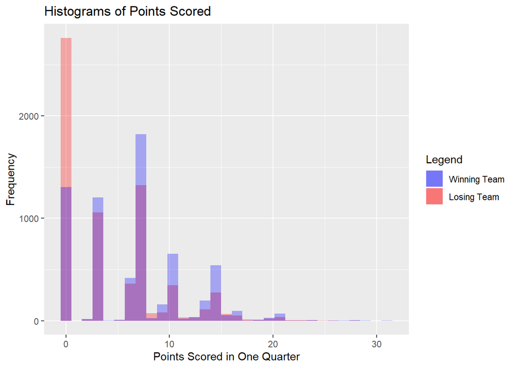

```r
#Get the individual observations from the points scored frequency mattrix.
pointsScoredObservations <- points_scored_observations(pointsScoredFrequency)

#Save the individual points scored matrix to file.
save(pointsScoredObservations, file="pointsScoredObservations.Rda")

#Load the ggplot2 library to creat a histogram with two distributions.
library(ggplot2)

#Create a histogram that graphs the winning team points scored and the losing team points scored separately.
ggplot() +
  geom_histogram(aes(x = pointsScoredObservations$losing_team_points_scored, fill = "r"), alpha = 0.3, bins = 31) +
  geom_histogram(aes(x = pointsScoredObservations$winning_team_points_scored, fill = "b"), alpha = 0.3, bins = 31) +
  scale_colour_manual(name ="Histograms of Points Scored", values = c("r" = "red", "b" = "blue"), labels=c("b" = "Winning Team", "r" = "Losing Team")) +
  scale_fill_manual(name ="Legend", values = c("r" = "red", "b" = "blue"), labels=c("b" = "Winning Team", "r" = "Losing Team"))+
  labs(title = "Histograms of Points Scored", x = "Points Scored in One Quarter", y = "Frequency")
```

The histogram above represents the distributions of points scored by each of the winning and losing teams. The winning teams are designated with the color blue and the losing teams are designated with the color red. It can be observed that the distributions are not normal. The same common scores (0,3,7,10…) and rare scores (2,4,5, 8…) noted previously are also displayed convincingly in this histogram. In terms of differences between the histograms. It can be observed that the losing teams score 0 points in a given quarter way more more often than the winning teams. If a team is losing at the start of a quarter, it is not surprising that they are more likely to score 0 points in that quarter because they are probably a worse offensive team. For the most part, the winning teams have more observations where the points scored is above 3 or above. However, there are three counter-examples that are interesting. When the points scored is 8, 11, or 15, there are more observations for the losing teams. If a team is losing, then they will play riskier in order to catch up to the team that is winning. Riskier play will result in teams that are more willing to go for a 2-point conversion attempt. If they are successful, then their points scored for that quarter will be a linear transformation of [3x+7y+8z] where 8 is equal to 1. The scores of 8, 11, and 15 are all likely in the described scenario.

#### Transiton Matrix

The transition matrix is constructed according to the two assumptions outlined in the previous section. They were:

Assumption #1: The points scored by each team is dependent. We should consider the points scored in the same quarter of the same game as dependent on each other.

Assumption #2: The points scored by each team is independent. We should consider distribution of points scored by the winning team and the losing team as two different distributions that exist separately.

For transition matrix one, the number of observations for each combination of points scored by the winning and losing teams is divided by the total number of observations. The resulting quotient is considered the relative frequency for that combination of points. If it is possible to get from one state to another state, there are usually two ways to get there. Either the winning team remained the winning team or the losing team became the winning team. The probability of both scenarios is calculated by adding the relevant points scored relative frequencies. All states where the winning team scored 94 or more points are considered an absorbing state. The justification for this decision is that it should not be possible to score 94 points in less than four quarters. This is based on the most points scored in a quarter being 31 points.

For transition matrix two, the number of observations for each row and column is divided by the total number of observations. The resulting quotients are considered the relative frequency for: the points scored by the winning team and the points scored by the losing team. Again if it is possible to get from one state to another state, there are usually two ways to get there. Either the winning team remained the winning team or the losing team became the winning team. The probability of the points scored by the winning team and the probability of the points scored by the losing team are assumed to be independent so they are directly multiplied by each other to calculate the probability of both events occurring. The scenarios that go from one state to the other are added together. All states where the winning or losing team scored 94 or more points are considered an absorbing state. The justification here is the same as the justification for the first transition matrix.

```r
#Load the states vector and the points scored frequency matrix.
load("states.Rda")
load("pointsScoredFrequency.Rda")

#Construct the first matrix based on assumption #1.
#transitionMatrixOne <- transition_matrix_one(states, pointsScoredFrequency) #This is the original line.
load("transitionMatrixOne.Rda")

#Save the first transition matrix to file.
save(transitionMatrixOne, file="transitionMatrixOne.Rda")

#Construct the second matrix based on assumption #2
#transitionMatrixTwo <- transition_matrix_two(states, pointsScoredFrequency) #This is the original line.
load("transitionMatrixTwo.Rda")

#Save the second transition matrix to file.
save(transitionMatrixTwo, file="transitionMatrixTwo.Rda")
```

# Results

### Using Markov Chains to Model Unique NFL Game Scores

#### State Probability Distributions with Standard Initial Distributions

The state probability distribution is calculated using the initial distribution, the transition matrix, and the number of steps (which are also known as the quarters to be played). The formula is written as:

transpose(transitionMatrix^steps)*initialDistribution

To calculate how often a Scorigami should occur in the average NFL game, the two transition matrices are tried, the standard initial distribution is used, and 4 steps are considered. The resulting state probability distribution is then conditioned so that only states that have never occurred before are considered. The sum of the remaining elements are calculated to find the probability of a scorigami.

```r
#Load the standard origin Matrix which designates that every game begins with a score of "0-0" with 100% probability.
load("standardInitialDistribution.Rda")

#Load the first transition matrix.
load("transitionMatrixOne.Rda")

#Calculate the state probability distribution after the 4 transitions.
#stateProbabilityDistributionOne <- state_probability_distribution(standardInitialDistribution, transitionMatrixOne, 4) #This is the original line.
load("stateProbabilityDistributionOne.Rda")

#Save state probability distribution to file.
save(stateProbabilityDistributionOne, file = "stateProbabilityDistributionOne.Rda")

#Load the second transition matrix.
load("transitionMatrixTwo.Rda")

#Calculate the state probability distribution after 4 transitions.
#stateProbabilityDistributionTwo <- state_probability_distribution(standardInitialDistribution, transitionMatrixTwo, 4) #This is the original line.
load("stateProbabilityDistributionTwo.Rda")

#Save state probability distribution to file.
save(stateProbabilityDistributionTwo, file = "stateProbabilityDistributionTwo.Rda")

#Load missing states vector from file.
load("missingStates.Rda")

#Print the scoigami probability of the statna
print(paste("The probability of a scorigami for transition matrix one, initial state of [0-0], and four quarters to play is ",scorigami_probability(stateProbabilityDistributionOne*100, missingStates), "%!", sep=""))
```

```
## [1] "The probability of a scorigami for transition matrix one, initial state of [0-0], and four quarters to play is 3.82443758589256%!"
```

```r
print(paste("The probability of a scorigami for transition matrix two, and initial state of [0-0], and four quarters to play is is ",scorigami_probability(stateProbabilityDistributionTwo*100, missingStates), "%!", sep=""))
```

```
## [1] "The probability of a scorigami for transition matrix two, and initial state of [0-0], and four quarters to play is is 4.11348803146902%!"
```

From the r output, the probability of a scorigami is 3.82% and 4.11%. Among the first 192 games of the 2019 NFL season, 4 have been considered scorigami. Those games include: Baltimore Ravens 59, Miami Dolphins 10; Tampa Bay Buccaneers 55, Los Angeles Rams 40; Cleveland Browns 40, Baltimore Ravens 25; and San Franciso 49ers 51, Carolina Panthers 13. Which can be verified on the NFL Scorigami website. The proportion of scorigami over the number of games in the 2019 season so far is 2.08%. This is close to the theoretical calculations.

#### State Probability Distributions with Interesting Scenarios

For the sake of interest, it is possible to look at different initial distributions at different starting periods. Two scenarios are outlined as having a good chance of generating a scorigami.

Scenario One: After 1 quarter, the score is tied at 2-2 as both teams managed to record a safety. Transition matrix one is used as the points scored per quarter for the two teams are considered dependent.

Scenario Two: After 3 quarters, the score is 32-2. Transition matrix two is used as the points scored per quarter for the two teams are considered independent.

```r
#Load the first transition matrix.
load("transitionMatrixOne.Rda")

#Load the second transition matrix.
load("transitionMatrixTwo.Rda")

#Load the states and missing states vectors.
load("states.Rda")
load("missingStates.Rda")

#stateProbabilityDistributionScenarioOne <- state_probability_distribution(initial_distribution(states, "2-2"), transitionMatrixOne, 3) #This is the original line.
load("stateProbabilityDistributionScenarioOne.Rda")

#Save the state probability distribution for scenario one.
save(stateProbabilityDistributionScenarioOne, file = "stateProbabilityDistributionScenarioOne.Rda")

print(paste("The probability of a scorigami for transition matrix one, initial state of [2-2], and three quarters to play is ",
            scorigami_probability(stateProbabilityDistributionScenarioOne*100, missingStates), "%!", sep=""))
```

```
## [1] "The probability of a scorigami for transition matrix one, initial state of [2-2], and three quarters to play is 28.7324679646835%!"
```

```r
#stateProbabilityDistributionScenarioTwo <- state_probability_distribution(initial_distribution(states, "32-2"), transitionMatrixTwo, 1) #This is the original line.
load("stateProbabilityDistributionScenarioTwo.Rda")

#Save the state probability distribution for scenario one.
save(stateProbabilityDistributionScenarioTwo, file = "stateProbabilityDistributionScenarioTwo.Rda")
print(paste("The probability of a scorigami for transition matrix two, initial state of [32-2], and one quarter to play is ",
            scorigami_probability(stateProbabilityDistributionScenarioTwo*100, missingStates), "%!", sep=""))
```

```
## [1] "The probability of a scorigami for transition matrix two, initial state of [32-2], and one quarter to play is 68.2218786498776%!"
```

The chance of a scorigami are fairly high in these two scenarios. the first has a probability of 28.7% while the second has a probability of 68.2%. Both states would be considered rare occurrences because they require either a 2-point safety or an 8-point touchdown with successful 2-point conversion to occur first. Once an rare state has been reached, it is more probable for the next state to be rare.

### Markov Chain Analysis

```r
library(markovchain)
#Create a markov chain object from transition matrix one.
#transitionMatrixOneMarkovChain <- new("markovchain", states = rownames(transitionMatrixOne), byrow = TRUE, transitionMatrix = transitionMatrixOne, name = "transitionMatrixOneMarkovChain") #This is the original line.
load("transitionMatrixOneMarkovChain.Rda")

#Save the markov chain object from transition matrix one to file.
save(transitionMatrixOneMarkovChain, file="transitionMatrixOneMarkovChain.Rda")

print(paste("For the transition matrix one markov chain. There are this many absorbing states: ", length(absorbingStates(transitionMatrixOneMarkovChain))))
```

```
## [1] "For the transition matrix one markov chain. There are this many absorbing states:  3410"
```

```r
if(is.irreducible(transitionMatrixOneMarkovChain)) {
  print("The markov chain is irreducible.")
} else {
  print("The markov chain is not irreducible.")
  print("The markov chain is not ergodic.")
  print("The mean first passage time is not defined.")
}
```

```
## [1] "The markov chain is not irreducible."
## [1] "The markov chain is not ergodic."
## [1] "The mean first passage time is not defined."
```

There are 3410 absorbing states which is every state where the winning team scores 94 or more points. The states were defined this way because there are only four quarters in a game and it was determined that to score 94 points it is necessary to play through at least quarters.

Given these absorbing states there is a steady state as eventually one of the two teams will reach at least 94 points and be absorbed if there is an infinite number of quarters. This result is not meaningful anyways as it is not possible to play more than 4 quarters in an NFL game. Even with overtime there the game will eventually end rather than continue to step Ad infinitum.

The markov chain is not irreducible. Thus the markov chain is not ergodic as well. When a future state is accessible from a past state, the past state is not accessible from the future state. This is because there is no way to remove points scored once they have been recorded. There are no classes with more than one state. All states where the winning team has less than 94 points are considered transient because it is not possible to return to the particular state once that state is left. All states where the winning team has 94 or more points are considered recurrent as they are absorbing states.

# Discussion & Conclusion

Points scored in one quarter were considered independent from points scored in another quarter for this analysis. If the variance of points scored is different between games compared to the variance of points scored within games, then the transition matrix would be different. The combination of the points scored by the winning and losing team has the same probability at every state according to the transition matrix. For example, going from state “14-10” to “28-24” has the same probability as going from state “40-3” to “54-17” (each team scores 14 points). More work can be done to determine whether scoring in one quarter is independent from other quarters in the same game. A more refined or complex construction of the transition matrix should probably consider the properties of the current state when calculating the probabilities of transitioning from one state to another.

Regardless, the models produced a probability of a scorigami that was not wildly different from the actual results. Given a larger sample size of real data, the actual and expected probability of a scorigami may converge. It also made a lot of intuitive sense that the chance of scorigami was very high when the scenario included a score that was rare or uncommon to begin with like “2-2” or “32-2”. As soon as a uncommon/rare way of scoring occurs the total score cannot be represented as a linear transformation in the form [3x+7y,3w+7z] which represents the most common ways to score.

The strength of the model can be evaluated by predicting the non-scorigami scores and testing whether that result aligns with real data. The prediction of a scorigami with a given initial distribution is difficult to verify because that score has never occurred before. If non-scorigami scores are considered, a state can be given and what states are most likely to be traveled to can be calculated with real data. A simpler approach would involve obtaining the distribution of actual final scores that occurred and comparing that to the state probability distributions produced by the markov chain models.

Overall, using markov chains to model unique NFL game scores is possible and produces results that align with the expectations of someone who is reasonably knowledgeable of the NFL. There are definitely more ways to construct the Markov chain compared to what was attempted in this analysis. Future work should focus on analyzing the assumptions made in this analysis in order to reject them or accept them.

# Works Cited

Bois, John. “Every NFL Score Ever | Chart Party”. *Youtube*, SB Nation, December 7, 2016, https://www.youtube.com/watch?v=9l5C8cGMueY.

Colon, David. “Jon Bois, editor at SB Nation, on making a career of weird sportswriting”. Brokelyn, August 3, 2015. https://brokelyn.com/howd-get-cool-job-jon-bois-sb-nation-making-career-weird-sportswriting/.

Horowitz, Marksim. “Introducing the nflscrapR Package”. Github, https://github.com/maksimhorowitz/nflscrapR. Accessesd 15 November 2019.

Jones, Chris. “The New Rules for NFL Overtime.” Mathematics Magazine, vol. 85, no. 4, 2012, pp. 277–283. JSTOR, www.jstor.org/stable/10.4169/math.mag.85.4.277.

Leake, Jacqueline & Pritchard, Nicholas. (2016) The Advantage of the Coin Toss for the New Overtime System in the National Football League, The College Mathematics Journal, 47:1, 2-9, DOI: 10.4169/college.math.j.47.1.2

NFL Scorigami. “NFL Scorigami”. Dec 2, 2019. https://nflscorigami.com/ Accessed 2 December 2019.

Nogle, Kevin. “Football 1010: The one-point safety”. The Phinsider, March 3, 2018. https://www.thephinsider.com/2018/3/3/17063556/football-101-the-one-point-safety.

Pro Football Reference. “All Game Scores in Pro Football History”. Dec 2, 2019. https://www.pro-football-reference.com/boxscores/game-scores.htm

Pro Football Reference. “Missing Games in Pro Football History”. Dec 2, 2019. https://www.pro-football-reference.com/boxscores/missing-scores.htm Accessed 2 December 2019.

# Appendix

Function library can be found at: https://github.com/austinredmond/ScorigamiMC/blob/master/ScorigamiMCLibrary.R